# Statistics Tutorial

## Generalized Linear Models (GLMs)

### Link functions

A Link Function is used in Generalized Linear Models (GLMs) to apply linear models for a continuous response variable given continuous and/or categorical predictors. A link function that is often used is called the inverse logit or logistic sigmoid function.

The link function provides a relationship between the linear predictor and the mean of a distribution.

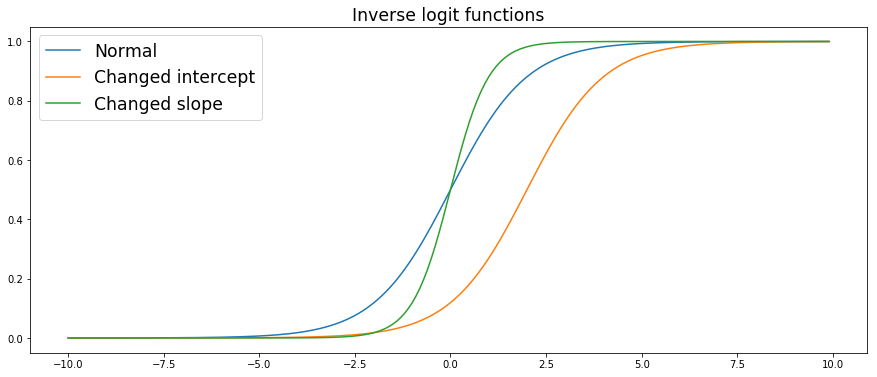

```python
# Inverse logit function (link function)
def inv_logit(x):
    return 1 / (1 + np.exp(-x))

t1 = np.arange(-10, 10, 0.1)
plt.figure(figsize=(15,6))
plt.plot(t1, inv_logit(t1),
         t1, inv_logit(t1-2),
         t1, inv_logit(t1*2))
plt.title('Inverse logit functions', fontsize='xx-large')
plt.legend(('Normal', 'Changed intercept', 'Changed slope'), fontsize='xx-large')
```

### Logistic regression

With logistic regression we use a link function like the inverse logit function mentioned above to model a binary dependent variable. While a linear regression model predicts the expected value of y given x directly, a GLM uses a link function.

We can easily implement logistic regression with [sklearn's Logistic Regression function.](https://scikit-learn.org/stable/modules/generated/sklearn.linear_model.LogisticRegression.html)

```python
# Simple example of Logistic Regression in Python
from sklearn.datasets import load_iris
X, y = load_iris(return_X_y=True)

# Logistic regression classifier
clf = LogisticRegression(random_state=0,
                         solver='lbfgs',
                         multi_class='multinomial').fit(X, y)

print('Accuracy score of logistic regression model on the Iris flower dataset: {}'.format(clf.score(X, y)))
```

```
Accuracy score of logistic regression model on the Iris flower dataset: 0.9733333333333334
```

## Frequentist vs. Bayes

Frequentist:

1. Fixed parameters (Processes are fixed)
2. Repeated sampling -> Probabilities

Bayes:

1. Probability as "degree of belief"
2. P(parameter) -> All plausible values of the parameter
3. Updates degree of belief based on a prior belief

Frequentists and Bayesians agree that Bayes' Theorem is valid. See figure below for explanation of this theorem.

[figure not shown]

Bayes theorem extends to distributions and random variables.

# The end!

**If you like this Kaggle kernel, feel free to give an upvote and leave a comment! I will try to implement your suggestions in this kernel!**

## Bonus: Free statistics courses

There is a lot of free material online for people who want to dive deeper into statistics. Here is a selection from the Internet.

Udacity's "Intro to Statistics": https://eu.udacity.com/course/intro-to-statistics--st101

Udacity's "Intro to Descriptive Statistics": https://eu.udacity.com/course/intro-to-descriptive-statistics--ud827

Udacity's "Intro to Inferential Statistics": https://eu.udacity.com/course/intro-to-inferential-statistics--ud201

edX's "Introduction to Probability - The Science of Uncertainty" : https://www.edx.org/course/introduction-probability-science-mitx-6-041x-2

Khan Academy's videos on statistics and probability: https://www.khanacademy.org/math/statistics-probability

(Kaggle Kernel) Mathematics of Linear Regression by Nathan Lauga: https://www.kaggle.com/nathanlauga/mathematics-of-linear-regression

## Sources

https://dataconomy.com/2015/02/introduction-to-bayes-theorem-with-python

https://www.statisticshowto.datasciencecentral.com/discrete-variable/

https://www.statisticshowto.datasciencecentral.com/probability-and-statistics/binomial-theorem/binomial-distribution-formula/

https://www.statisticshowto.datasciencecentral.com/probability-and-statistics/descriptive-statistics/sample-variance/

https://machinelearningmastery.com/a-gentle-introduction-to-the-bootstrap-method

https://machinelearningmastery.com/k-fold-cross-validation/

https://en.wikipedia.org/wiki/Poisson_distribution

https://www.tutorialspoint.com/python/python_p_value.htm

https://towardsdatascience.com/inferential-statistics-series-t-test-using-numpy-2718f8f9bf2f

https://www.slideshare.net/dessybudiyanti/simple-linier-regression

https://www.youtube.com/channel/UCgBncpylJ1kiVaPyP-PZauQ

https://en.wikipedia.org/wiki/Bias%E2%80%93variance_tradeoff